# Exploring the BRFSS data

## Setup

### Load packages

```r
library(ggplot2)
library(dplyr)
```

### Load data

```r
library(ggplot2)
library(dplyr)
load("brfss2013.RData")
```

## Part 1: Data

According to its documentation, the Behavioral Risk Factor Surveillance System (BRFSS) contains data that is designed to measure behavioral risk factors for the non-instituionalized adult (older than 18) residing in the US teritories. The data was collected by both landline telephone and cellphone based surveys, and all interviewers were randomly selected.

The study can be categorized as a random sampling observational study. Therefore, it will be difficult to draw causal conclusions based on the datasets since there is no random assignments or any experiments involved. However, it can be generalized to the US population since the data was collected using random sampling.

## Part 2: Research questions

**Research quesion 1:** How successful are smokers in quitting their smoking habits?

**Research quesion 2:** Is there any correlation between people’s income level and their dietary habits in terms of fruit and vegetable intake?

**Research quesion 3:** Is there any correlation between people’s smoking habits and their level of physical activities? Is there any gender difference as well?

## Part 3: Exploratory data analysis

### Research question 1:

In this exploratory analysis, I would like to understand how successful people are in quitting their smoking habits. In particular, I would like to know if people tend to smoke less after they decided to quit smoking. To perform this analysis, we target on the group who have smoked more than 100 cigarettes in their entire lifetime, and who have decided to quit smoking in the past twelve months. We then compare their current smoking habits with the group who have not decided to quit smoking to gain some insights into their success in quitting smoking.

Three variables are used for this study:

- **smoke100**: Smoked At Least 100 Cigarettes
  - Have you smoked at least 100 cigarettes in your entire life? [Note: 5 packs = 100 cigarettes]
- **stopsmk2**: Stopped Smoking In Past 12 Months
  - During the past 12 months, have you stopped smoking for one day or longer because you were trying to quit smoking?
- **smokday2**: Frequency Of Days Now Smoking
  - Do you now smoke cigarettes every day, some days, or not at all?

Let create a subset of the data and remove all NA values.

```r
df1 = brfss2013[, c("smoke100", "stopsmk2", "smokday2")]
df1 = df1[complete.cases(df1) & df1$smoke100=="Yes", ] # targeting people who have smoked more than 100 cigarettes
summary(df1)
```

```
##  smoke100    stopsmk2          smokday2
##  Yes:76351   Yes:43716   Every day :55031
##  No :    0   No :32635   Some days :21320
##                          Not at all:    0
```

From the summary statistics, it is interesting to see that the count of `Not at all` category in the `smokday2` variable is zero. This indicates that no one has completed quitted smoking. Let’s group our data by `stopsmk2` and `smokday2` and calculate the total count for each group

```r
g_df1 <- df1 %>%
    group_by(stopsmk2, smokday2) %>%  # group data
    summarise(ct=n()) %>%     # calcualte total count for each group
    mutate(freq=ct/sum(ct)) %>%   # calculate percentage frequency for each group
    mutate(pos=(cumsum(freq) - 0.5 * freq)) # calculate position for value labels for barcharts
g_df1[, c("stopsmk2", "smokday2", "ct")]
```

```
## Source: local data frame [4 x 3]
## Groups: stopsmk2 [2]
##
##   stopsmk2  smokday2    ct
##     <fctr>    <fctr> <int>
## 1      Yes Every day 27429
## 2      Yes Some days 16287
## 3       No Every day 27602
## 4       No Some days  5033
```

We can visualize the above numeric results using a stacked barcharts

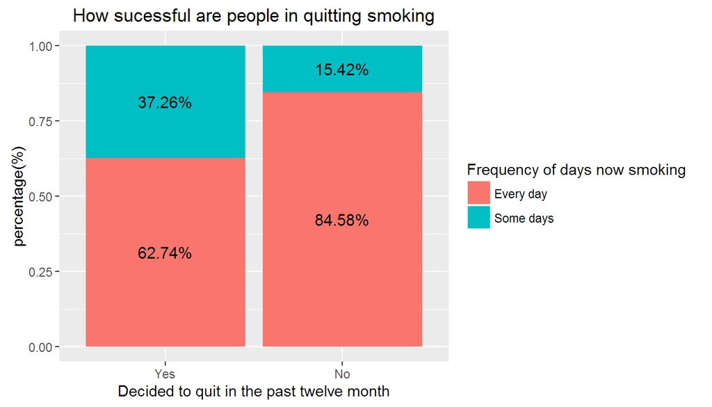

```r
ggplot(data=g_df1, aes(x=factor(stopsmk2), y=freq, fill=smokday2)) +
        geom_bar(stat="identity") + geom_text(aes(x = stopsmk2, y = pos,
                                                  label=paste0(sprintf("%.2f", 100*freq), "%")), size=4) +
        labs(title = "How sucessful are people in quitting smoking", x = "Decided to quit in the past twelve month", y = "percentage(%)") + scale_fill_discrete(name="Frequency of days now smoking")
```

From the above barplots, we can see that there is still **~63%** of people who smokes on a daily basis in the ‘quit smoking’ group. **None** of them quit smoking completely since rest of the people still smoke on “some days”.

Without having access to data of people’s smoking frequency **before** they decided to quit smoking, it is difficult to rate their success. However, the results seems to suggest that people who have decided to quit smoking tends to have a smaller portion of regular smoker than people never thought about quitting in the past twelve months.

### Research question 2

Let’s first create a subset of data and remove all NA values

```r
df2 = brfss2013[, c("X_incomg", "ftjuda1_", "vegeda1_")]
names(df2) = c("income", "fruit_intake", "vege_intake")
df2 = df2[complete.cases(df2), ]
summary(df2)
```

```
##                           income        fruit_intake     vege_intake
##  Less than $15,000           : 46503   Min.   :   0.0   Min.   :   0.00
##  $15,000 to less than $25,000: 69067   1st Qu.:   0.0   1st Qu.:  40.00
##  $25,000 to less than $35,000: 44641   Median :  13.0   Median :  71.00
##  $35,000 to less than $50,000: 56997   Mean   :  39.1   Mean   :  80.91
##  $50,000 or more             :170331   3rd Qu.:  67.0   3rd Qu.: 100.00
##                                        Max.   :9900.0   Max.   :9900.00
```

In this dataset, we have 1 categorical variable(`income`) and two numerical variables(`fruit_intake` and `vege_intake`). To compare the distribution of different income group, we can use boxplot charts for data visualizations

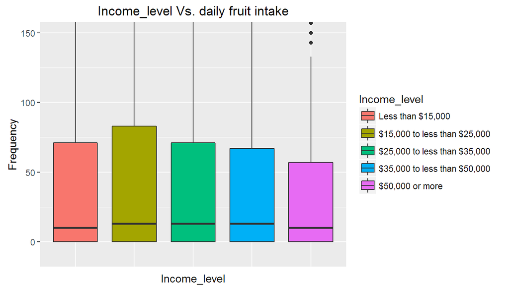

```r
# Correlation between income level and daily fruit intake
ggplot(aes(y = fruit_intake, x = income, fill=income), data = df2) +
           geom_boxplot() + theme(axis.text.x=element_blank(),axis.ticks.x=element_blank())+
           coord_cartesian(ylim = c(-10, 150)) +
           labs(title = "Income_level Vs. daily fruit intake", x = "Income_level", y = "Frequency") +
                scale_fill_discrete(name="Income_level")
```

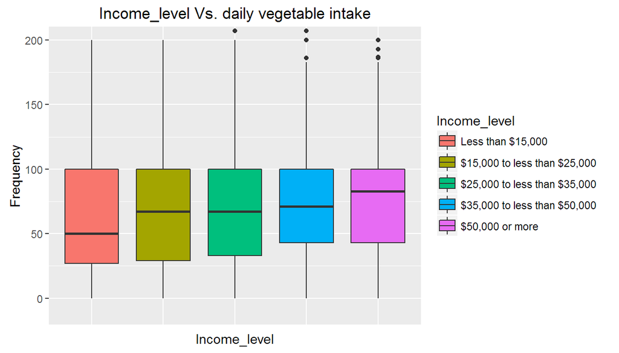

```r
# Correlation between income level and daily vegetable intake
ggplot(aes(y = vege_intake, x = income, fill=income), data = df2) +
           geom_boxplot() + theme(axis.text.x=element_blank(),axis.ticks.x=element_blank())+
           coord_cartesian(ylim = c(-10, 200)) +
           labs(title = "Income_level Vs. daily vegetable intake", x = "Income_level", y = "Frequency") + scale_fill_discrete(name="Income_level")
```

For the vegetable intake, the **median** value shows an increasing trend with income level and also a tighter distribution (smaller IQR) with increasing income level. This result indicates that people in the higher income group tends to eat more vegetables.

### Research quesion 3:

There is a common conception that people who do not smoke tends to have a more healthy lifestyle and would engage in more physical activities. In this study, we would like to explore the correlation between people’s smoking habits and their physical activity levels. We would also like to know if there is any gender difference involved.

Three variables are chosen:

- **sex**: people’s gender
- **_rfsmok3**: current smoking calculated variable
  - calculated variable for adults who are current smokers
- **_pacat1**: physical activity categories

Let’s first create a data subset and remove all NA values

```r
df3 = brfss2013[, c("sex", "X_rfsmok3", "X_pacat1")]
df3 = df3[complete.cases(df3),]
names(df3) = c("sex", "smoker", "activity_level")
summary(df3)
```

```
##      sex         smoker                     activity_level
##  Male  :169082   No :346466   Highly active        :134193
##  Female:244007   Yes: 66623   Active               : 71219
##                               Insufficiently active: 77541
##                               Inactive             :130136
```

All three variables are categorical. We will visualize the data using stacked barcharts

```r
g_df3 = df3 %>%
        group_by(sex, smoker, activity_level) %>%
        summarise(ct=n()) %>%     # calcualte total count for each group
        mutate(freq=100*ct/sum(ct)) %>%   # calculate frequency for each group
        mutate(pos=(cumsum(freq) - 0.5 * freq)) # calculate position for value labels
```

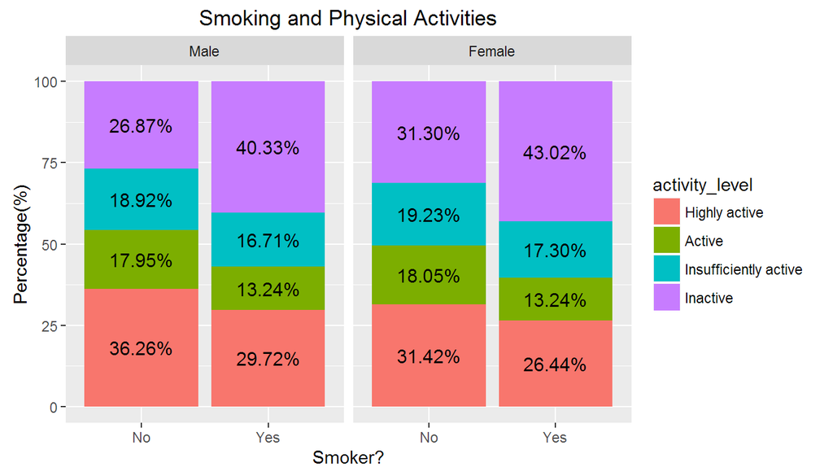

```r
ggplot(data=g_df3, aes(x=factor(smoker), y=freq, fill=activity_level)) + geom_bar(stat='identity')+
      facet_wrap( ~ sex, ncol=2) +
      geom_text(aes(x = smoker, y = pos, ymax = 15, label=paste0(sprintf("%.2f", freq), "%")), size=4) +
      labs(title = "Smoking and Physical Activities", x = "Smoker?", y = "Percentage(%)")
```